# SU_25_River_Rockfish_Proj_Fecundity_Ambient_V0.2

River Mckegney

2025-07-22

## Setup, and Packages

Code Packages:

```r
# Load packages
library(gridExtra) # For using grid.table to save tables as images
library(flextable) # Alternative method to save df as image
library(tidyverse)
library(zoo)
library(lme4)
library(lmerTest)
library(rlang)
library(nortest) # For ad.test
library(car) # For homogeneity of variance with leveneTest
library(rcompanion) # For scheirerRayHare test
library(pastecs) # For stat.desc
library(ggpubr) # For assumption plots
library(conover.test) # For the conover.Iman() test function
library(DescTools) # Contain alternative ConoverTest function
library(rstatix) # tidyverse adapted stat tests and mshapiro_test() functions
library(DHARMa) # For multi-level lm models and shapiro test
library(patchwork) # For combining ggplots
```

## Data Entry: Read-in data

```r
# Read and call data into df

# Primary samples df
ABL90 <- read.csv("Raw_Data/ABL90_Raw.csv")

# River's Parturition metadata
partuition_subcat <- read.csv("Raw_Data/River's_Rockfish_Metadata_Parturition_V7.csv")
```

## Data Filtering

```r
# Data sifting: ABL90 dataset

# Step 1: Remove missing info
ABL_set1 <- ABL90 %>%
  filter(Patient.ID_edited != "")


# Step 2: Separate Patient.ID into columns of sample types: blood plasma and instant freeze plasma
ABL_set2 <- separate(ABL_set1, 'Patient.ID_edited', into = c("Patient.ID_edited", "Sample_Type"), sep = ",")
# Step 3:
# Convert Patient.ID_edited column data to character type
ABL_set2$Patient.ID_edited <- as.character(ABL_set2$Patient.ID_edited)
```

```r
# Step 4 & 5: Sussing out specific sample errors

# Remove insufficient samples
ABL_set3 <- ABL_set2 %>%
  filter(!is.na("Type")) %>%
  filter(!str_detect(Errors.detected.during.measurement, "Insufficient sample"))

# Remove inhomogeneous samples
ABL_set3 <- ABL_set3 %>%
  filter(!is.na("Type")) %>%
  filter(!str_detect(Errors.detected.during.measurement, "Inhomogeneous sample"))

# Step 6: Filter for only blood samples
ABL_b_samp <- ABL_set3 %>%
  filter(Sample_Type == "b")
```

## Merge Datasets:

Join ABL90 df with parturition_subcat df: Making ABL_merged

```r
# Rename columns to match: Change 'ID' in parturition_subcat to 'Patient.ID_edited' so it is ready to join with ABL90 df

# Please note the 'Treatment' col in parturition_subcat does not match with the finalized 'Ambient.Or.OAH' col in metadata_atresia_guide or ABL90_merged df

# Rename 'ID' col to 'patient.ID_edited'
partuition_subcat <- partuition_subcat %>%
  rename(Patient.ID_edited = ID)
```

```r
# Connect main ABL90 dataset with my (River's) sub categorized parturition metadata
# ABL_merged <- partuition_subcat %>%
# left_join(ABL_b_samp, by = "Patient.ID_edited")

ABL_merged <- ABL_b_samp %>%
inner_join(partuition_subcat, by = "Patient.ID_edited")
```

Rename Columns Neatly:

```r
# Rename Treatment & Parturition Outcome
ABL_merged <- ABL_merged %>%
  rename(Ambient.Or.OAH = Consensus_General_Treatment,
         Pregnant.Or.Atresia = Consensus_Atresia_Or_Pregnant)
```

## Remove Samples: Mortalities, NA’s, or Missing Info, and Replicates

Remove Replicate ID’s

```r
# Cross Check all Columns: Cross validation to suss correct replicate row
check_params <- ABL_merged %>%
  select(Patient.ID_edited, Time, Sample.., Measuring.Mode, Ambient.Or.OAH, Pregnant.Or.Atresia, pH, Glu..mmol.L., Hct...., Na...mmol.L., Cl...mmol.L., K...mmol.L., Ca....mmol.L., pCO2..mmHg.) %>%
  filter(Patient.ID_edited == "9782D")
print(check_params)
```

```
##   Patient.ID_edited             Time Sample.. Measuring.Mode Ambient.Or.OAH
## 1             9782D 12/28/2023 10:04     1016         C 65uL        Ambient
## 2             9782D   1/9/2024 17:21      863         S 65uL        Ambient
##   Pregnant.Or.Atresia    pH Glu..mmol.L. Hct.... Na...mmol.L. Cl...mmol.L.
## 1    Post Parturition 7.348          0.5     9.8          184          149
## 2    Post Parturition 7.446          0.7    13.3          181          161
##   K...mmol.L. Ca....mmol.L. pCO2..mmHg.
## 1         2.8          1.32         4.2
## 2         2.9          1.31         6.8
```

```r
check_params <- ABL_merged %>%
  select(Patient.ID_edited, Time, Sample.., Measuring.Mode, Ambient.Or.OAH, Pregnant.Or.Atresia, pH, Glu..mmol.L., Hct...., Na...mmol.L., Cl...mmol.L., K...mmol.L., Ca....mmol.L., pCO2..mmHg.) %>%
  filter(Patient.ID_edited == "9783D")
print(check_params)
```

```
##   Patient.ID_edited            Time Sample.. Measuring.Mode Ambient.Or.OAH
## 1             9783D 1/19/2024 10:37      934         S 65uL        Ambient
## 2             9783D  1/7/2024 12:32      860         S 65uL        Ambient
##   Pregnant.Or.Atresia    pH Glu..mmol.L. Hct.... Na...mmol.L. Cl...mmol.L.
## 1    Post Parturition 7.484          1.7     0.2          175          193
## 2    Post Parturition 7.450          1.3    14.7          179          164
##   K...mmol.L. Ca....mmol.L. pCO2..mmHg.
## 1        34.5          1.29         8.5
## 2         2.5          1.30         5.3
```

```r
# Removed replicates: 9782D (2x) and 9783D (2x)
ABL_merged <- ABL_merged %>%
  filter(Sample.. != "863",
         Sample.. != "934")
```

Review Replicates:

| Row | ID | Time | Sample.. | Measuring.Mode | pH | Glu.mmol.L. | Hct…. | Na…mmol.L. | Cl…mmol.L. | K…mmol.L. | Ca.mmol.L. |
| --- | --- | --- | --- | --- | --- | --- | --- | --- | --- | --- | --- |
| 32 | 9782D | 12/28/2023 10:04 | 1016 | C 65uL | 7.348 | 0.5 | 9.8 | 184 | 149 | 2.8 | 1.32 |
| 39 | 9782D | 1/9/2024 17:21 | 863 | S 65uL | 7.446 | 0.7 | 13.3 | 181 | 161 | 2.9 | 1.31 |
| 36 | 9783D | 1/19/2024 10:37 | 934 | S 65uL | 7.484 | 1.7 | **0.2** | 175 | 193 | **34.5** | 1.29 |
| 41 | 9783D | 1/7/2024 12:32 | 860 | S 65uL | 7.450 | 1.3 | **14.7** | 179 | 164 | **2.5** | 1.30 |

Methods for replicate sample removal: Check processing date of IDs, and remove samples that do not match that date.

Case ID_9782D:

- Origianl ABL90 set contains:
- 9782D,b (Sample.. 1016, Time = 12/28/2023 10:04:00 AM)
- 9782D,p (Sample.. 1020, Time = 12/28/2023 10:25:00 AM)
- 9782D,p (Sample.. 865, Time = 1/9/2024 5:29:00 PM)
- 9782D,b (Sample.. 863, Time = 1/9/2024 5:21:00 PM)
- 2024_Fish_Metadata.csv says ID_9782D was processed 3/29/2024
- Note Processing date in metadata will not match time date stamp in ABL90 data due to the machine being reset, and innacurrate dates being automatically recorded.

Deciding info: - For ID-9782D, refer to metadata sheet and look for other samples with that same processing date, then view thoes samples ABL90 ‘Time’. Try to find a matching ‘Time’ with other IDs and 9782D that were processed together during the same time recorded by the machine.

Case ID_9783D

- Original ABL90 dataset contains:
- 9783D,b (Sample.. 934, Time = 1/19/2024 10:37:00 AM)
- 9783D,c (Sample.. 861, Time = 1/7/2024 12:38:00 PM)
- 9783D,b (Sample.. 860, Time = 1/7/2024 12:32:00 PM)
- 2024_Fish_Metadata.csv says ID_9783D was processed 3/20/2024
- Informed that ID_9783D: Sample.. 934 is a plasma sample (on account of its low hct value), remove this and **keep Sample.. 860 (parameter values appear correct)**.

# Samples: Data subsets

Remove Motalities and No info IDs and assign analysis ready data-frames:

```r
# New df with Moralities removed: Note none of these samples made it into ABL90 df anyway, so looks like they are already filtered out.
 Live_Samples <- ABL_merged %>%
  filter(Patient.ID_edited != "9780C", # Mortality
         Patient.ID_edited != "777AE", # Mortality
         Patient.ID_edited != "777CA") # Mortality after parturition


# New df with mortality and 'No info' Id's removed
 Primary_Samples <- Live_Samples %>%
   filter(Patient.ID_edited != "777A0", # No info
           Patient.ID_edited != "9782F", # No info
           Patient.ID_edited != "777B3", # No info
           Patient.ID_edited != "777AA", # No info
           Patient.ID_edited != "777DE", # No info
           Patient.ID_edited != "777CE", # No info
           Patient.ID_edited != "777A6") # No info


# New df of Only Ambient Treatment: For testing parturition success
 Ambient_Samples <- Primary_Samples %>%
   filter(Ambient.Or.OAH == "Ambient")

# New df of Fecundity Samples:
 Fecundity_Samples <- Primary_Samples %>%
   filter(Fecundity_Or_Brood_Count != "NA",
     Fecundity_Class != "NA") # removes 97706

# Fecundity samples without atresia Ids
 Fecundity_No_Atresia_Samples <- Primary_Samples %>%
   filter(All_Fecundity != "Na",
          All_Fecundity != 0)  # removes atresia IDs

# Fecundity Ambient Samples
 Amb_Fec_Samples <- Primary_Samples %>%
   filter(Ambient.Or.OAH == "Ambient",
          All_Fecundity != "NA") # removes OAH treatment samples and ID 97706

# Fecundity Ambient Samples without atresia Ids
 Amb_Fec_No_Atresia_Samples <- Primary_Samples %>%
   filter(Ambient.Or.OAH == "Ambient", # removes OAH treatment
          All_Fecundity != "NA", # removes all missing info IDs
          All_Fecundity != 0) # removes atresia IDs
```

Change Data Types:

```r
# Change Continuous Data to type to numeric, double, or factor

# Change data type of ions to factor or numeric
#glimpse(General_Samples)
#glimpse(Ambient_Samples)

Primary_Samples <- Primary_Samples %>%
  mutate(across(c(pH, Hct...., Glu..mmol.L., Na...mmol.L., Cl...mmol.L., K...mmol.L., Ca....mmol.L.), as.numeric))

Ambient_Samples <- Ambient_Samples %>%
  mutate(across(c(pH, Hct...., Glu..mmol.L., Na...mmol.L., Cl...mmol.L., K...mmol.L., Ca....mmol.L.), as.numeric))

Fecundity_Samples <- Fecundity_Samples %>%
  mutate(across(c(All_Fecundity, pH, Hct...., Glu..mmol.L., Na...mmol.L., Cl...mmol.L., K...mmol.L., Ca....mmol.L.), as.numeric))

Fecundity_No_Atresia_Samples <- Fecundity_Samples %>%
  mutate(across(c(All_Fecundity, pH, Hct...., Glu..mmol.L., Na...mmol.L., Cl...mmol.L., K...mmol.L., Ca....mmol.L.), as.numeric))

Amb_Fec_Samples <- Amb_Fec_Samples %>%
  mutate(across(c(All_Fecundity, pH, Hct...., Glu..mmol.L., Na...mmol.L., Cl...mmol.L., K...mmol.L., Ca....mmol.L.), as.numeric))

Amb_Fec_No_Atresia_Samples <- Amb_Fec_No_Atresia_Samples %>%
  mutate(across(c(All_Fecundity, pH, Hct...., Glu..mmol.L., Na...mmol.L., Cl...mmol.L., K...mmol.L., Ca....mmol.L.), as.numeric))

# glimpse(Primary_Samples)
# glimpse(Ambient_Samples)
# glimpse(Fecundity_Samples)
# glimpse(Fecundity_Count_Samples)
# glimpse(Amb_Fec_Samples)
```

## Order Factor Levels

```r
# Fecundity data

#unique(Fecundity_Samples$Fecundity_Class)

# Arrange the order of parturition categories for visualizations & tests
Fecundity_Samples$Fecundity_Class <- ordered(Fecundity_Samples$Fecundity_Class, levels = c("High (>50,000)", "Low (~1,000s)", "Atresia"))

Fecundity_No_Atresia_Samples$Fecundity_Class <-
  ordered(Fecundity_No_Atresia_Samples$Fecundity_Class, levels = c("High (>50,000)", "Low (~1,000s)", "Atresia"))

Amb_Fec_Samples$Fecundity_Class <- ordered(Amb_Fec_Samples$Fecundity_Class, levels = c("High (>50,000)", "Low (~1,000s)", "Atresia"))

Amb_Fec_No_Atresia_Samples$Fecundity_Class <- ordered(Amb_Fec_No_Atresia_Samples$Fecundity_Class, levels = c("High (>50,000)", "Low (~1,000s)", "Atresia"))
```

# Save filtered dataset into data-worked folder

```r
# Save merged dataset in a worked folder

write.csv(x = Primary_Samples, file = "Worked-Data/Primary_Samples")

write.csv(x = Ambient_Samples, file = "Worked-Data/Ambient_Samples")

write.csv(x = Fecundity_Samples, file = "Worked-Data/Fecundity_Samples")

write.csv(x = Fecundity_No_Atresia_Samples, file = "Worked-Data/Fecundity_No_Atresia_Samples")

write.csv(x = Amb_Fec_Samples, file = "Worked-Data/Amb-Fec_Samples")

write.csv(x = Amb_Fec_No_Atresia_Samples, file = "Worked-Data/Amb_Fec_No_Atresia_Samples")
```

## Sample Size: n

```r
# Sample Size

# Ambient Fecundity data:
amb_fec_sample_size_table <- Amb_Fec_Samples %>%
  group_by(Ambient.Or.OAH, Fecundity_Class) %>%
  summarise(n_size = n_distinct(Patient.ID_edited), .groups = "drop")
print(amb_fec_sample_size_table)
```

```
## # A tibble: 3 × 3
##   Ambient.Or.OAH Fecundity_Class n_size
##   <chr>          <ord>            <int>
## 1 Ambient        High (>50,000)       4
## 2 Ambient        Low (~1,000s)        4
## 3 Ambient        Atresia             13
```

```r
 pdf("data-images/amb_fec_sample_size_table.pdf")
 grid.table(amb_fec_sample_size_table)
 dev.off()
```

```r
 png("data-images/amb_fec_sample_size_table.png")
 grid.table(amb_fec_sample_size_table)
 dev.off()
```

```r
# Ambient Fecundity No Atresia data:

amb_fec_no_atresia_sample_size_table <- Amb_Fec_No_Atresia_Samples %>%
  group_by(Ambient.Or.OAH, Fecundity_Class) %>%
  summarise(n_size = n_distinct(Patient.ID_edited), .groups = "drop")
print(amb_fec_no_atresia_sample_size_table)
```

```
## # A tibble: 2 × 3
##   Ambient.Or.OAH Fecundity_Class n_size
##   <chr>          <ord>            <int>
## 1 Ambient        High (>50,000)       4
## 2 Ambient        Low (~1,000s)        4
```

```r
 pdf("data-images/amb_fec_no_atresia_sample_size_table.pdf")
 grid.table(amb_fec_no_atresia_sample_size_table)
 dev.off()
```

```r
 png("data-images/amb_fec_no_atresia_sample_size_table.png")
 grid.table(amb_fec_no_atresia_sample_size_table)
 dev.off()
```

Sample Size Barplot:

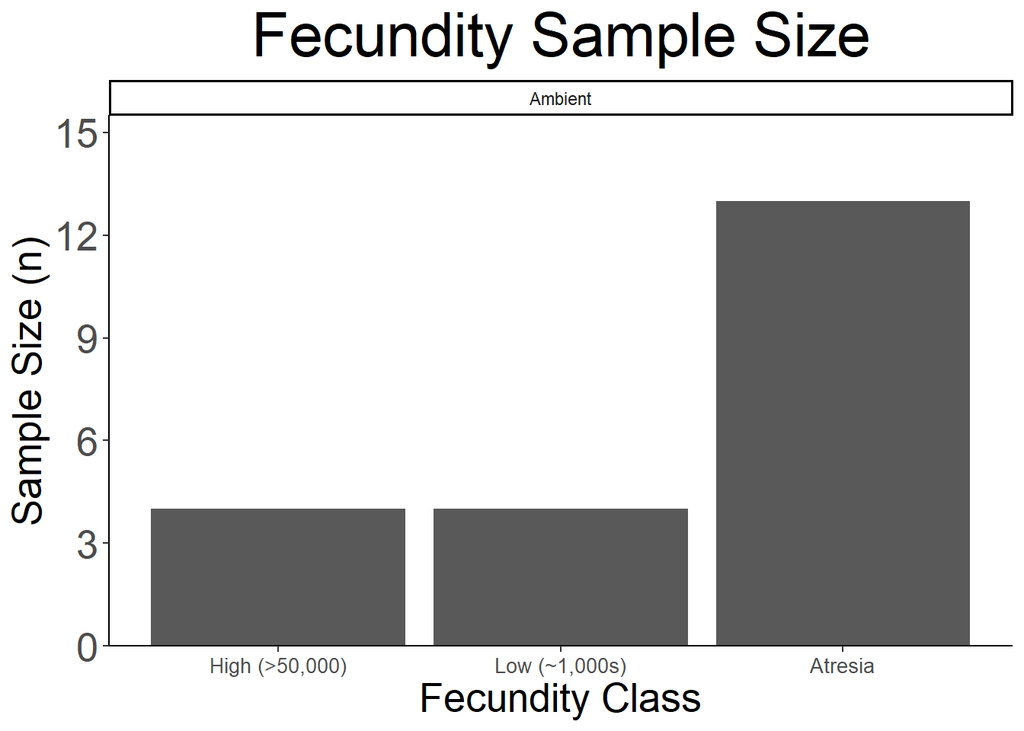

```r
# View Sample Distributions

# Sample Size barplot

# Ambient Fecundity data
amb_fec_sample_size_barplot <- Amb_Fec_Samples %>%
  group_by(Ambient.Or.OAH, Fecundity_Class) %>%
  summarise(n_size = n_distinct(Patient.ID_edited), .groups = "drop") %>%
  ggplot(aes(x = Fecundity_Class, y = n_size)) +
  geom_bar(stat = "identity") +
  facet_grid(~ Ambient.Or.OAH) +
  scale_y_continuous(expand = c(0, 0), limits = c(0, 15.5), breaks = c(0, 3, 6, 9, 12, 15)) +
  labs(title = "Fecundity Sample Size",
        x = "Fecundity Class",
        y = "Sample Size (n)") +
  theme_classic() +
  theme(panel.background = element_rect(fill = "white"),
        plot.background = element_rect(fill = "white"),
        legend.background = element_rect(fill = "white", color = "black"),
        title = element_text(size = 12),
        plot.title = element_text(size = 30, hjust = 0.5),
        axis.text.x = element_text(size = 10),
        axis.text.y = element_text(size = 20),
        axis.title.x = element_text(size = 20),
        axis.title.y = element_text(size = 20))

print(amb_fec_sample_size_barplot)
```

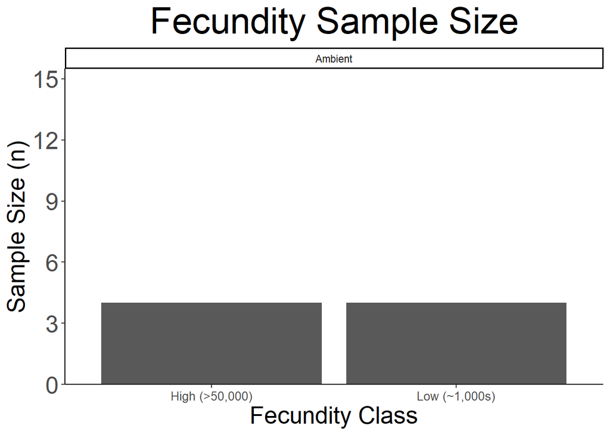

```r
ggsave(filename = "data-images/.png", plot = amb_fec_sample_size_barplot, device = "png")
ggsave(filename = "data-images/amb_fec_sample_size_barplot.pdf", plot = amb_fec_sample_size_barplot, device = "pdf")
# Ambient Fecundity No Atresia data
amb_fec_no_atresia_sample_size_barplot <- Amb_Fec_No_Atresia_Samples %>%
  group_by(Ambient.Or.OAH, Fecundity_Class) %>%
  summarise(n_size = n_distinct(Patient.ID_edited), .groups = "drop") %>%
  ggplot(aes(x = Fecundity_Class, y = n_size)) +
  geom_bar(stat = "identity") +
  facet_grid(~ Ambient.Or.OAH) +
  scale_y_continuous(expand = c(0, 0), limits = c(0, 15.5), breaks = c(0, 3, 6, 9, 12, 15)) +
  labs(title = "Fecundity Sample Size",
        x = "Fecundity Class",
        y = "Sample Size (n)") +
  theme_classic() +
  theme(panel.background = element_rect(fill = "white"),
        plot.background = element_rect(fill = "white"),
        legend.background = element_rect(fill = "white", color = "black"),
        title = element_text(size = 12),
        plot.title = element_text(size = 30, hjust = 0.5),
        axis.text.x = element_text(size = 10),
        axis.text.y = element_text(size = 20),
        axis.title.x = element_text(size = 20),
        axis.title.y = element_text(size = 20))

print(amb_fec_no_atresia_sample_size_barplot)
```

```r
ggsave(filename = "data-images/amb_fec_no_atresia_sample_size_barplot.png", plot = amb_fec_no_atresia_sample_size_barplot, device = "png")
ggsave(filename = "data-images/amb_fec_no_atresia_sample_size_barplot.pdf", plot = amb_fec_no_atresia_sample_size_barplot, device = "pdf")
```

Note: Amb Fec No Atreisa Sample subset is a low n-size, but balanced.

# pH

pH Summary Stats

```r
# pH
# Summary stats

# Amb Fec data (with atresia IDs)
Amb_Fec_Samples %>%
  group_by(Ambient.Or.OAH, Fecundity_Class) %>%
  summarize(count = n(),
            median = round(median(pH), 3),
            mean = round(mean(pH), 3),
            sd = round(sd(pH), 3),
            cv = round(sd(pH)/mean(pH), 3)) %>%
  ungroup()
```

```
## # A tibble: 3 × 7
##   Ambient.Or.OAH Fecundity_Class count median  mean    sd    cv
##   <chr>          <ord>           <int>  <dbl> <dbl> <dbl> <dbl>
## 1 Ambient        High (>50,000)      4   7.44  7.43 0.076 0.01
## 2 Ambient        Low (~1,000s)       4   7.46  7.45 0.054 0.007
## 3 Ambient        Atresia            13   7.37  7.38 0.1   0.014
```

```r
# Amb Fec No Atresia data
Amb_Fec_No_Atresia_Samples %>%
  group_by(Ambient.Or.OAH, Fecundity_Class) %>%
  summarize(count = n(),
            median = round(median(pH), 3),
            mean = round(mean(pH), 3),
            sd = round(sd(pH), 3),
            cv = round(sd(pH)/mean(pH), 3)) %>%
  ungroup()
```

```
## # A tibble: 2 × 7
##   Ambient.Or.OAH Fecundity_Class count median  mean    sd    cv
##   <chr>          <ord>           <int>  <dbl> <dbl> <dbl> <dbl>
## 1 Ambient        High (>50,000)      4   7.44  7.43 0.076 0.01
## 2 Ambient        Low (~1,000s)       4   7.46  7.45 0.054 0.007
```

Data Graphs:

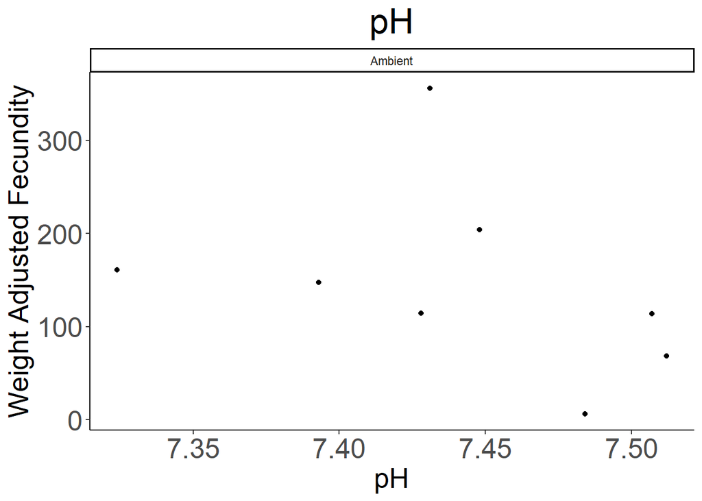

```r
# pH
# Weight adjusted scatterplot

# Amb Fec only scatterplot: atresia ids removed
pH_amb_fec_no_atresia_weight_adj_scatterplot <- ggplot(data = Amb_Fec_No_Atresia_Samples) +
  geom_point(aes(x = pH, y = Weight_Adjusted_Fecundity_Fecundity.Mean_Weight), colour = "black") +
  labs(title = "pH", x = "pH", y = "Weight Adjusted Fecundity") +
  scale_y_continuous() +
  theme_classic() +
  facet_wrap(~ Ambient.Or.OAH) +
  theme(panel.background = element_rect(fill = "white"),
        plot.background = element_rect(fill = "white"),
        legend.background = element_rect(fill = "white", color = "black"),
        plot.title = element_text(size = 25, hjust = 0.5),
        axis.text.x = element_text(size = 20),
        axis.text.y = element_text(size = 20),
        axis.title.x = element_text(size = 20),
        axis.title.y = element_text(size = 20))

print(pH_amb_fec_no_atresia_weight_adj_scatterplot)
```

```r
ggsave(filename = "data-images/pH_amb_fec_no_atresia_weight_adj_scatterplot.pdf", plot = pH_amb_fec_no_atresia_weight_adj_scatterplot, device = "pdf")
ggsave(filename = "data-images/pH_amb_fec_no_atresia_weight_adj_scatterplot.png", plot = pH_amb_fec_no_atresia_weight_adj_scatterplot, device = "png")
```

pH Boxplot

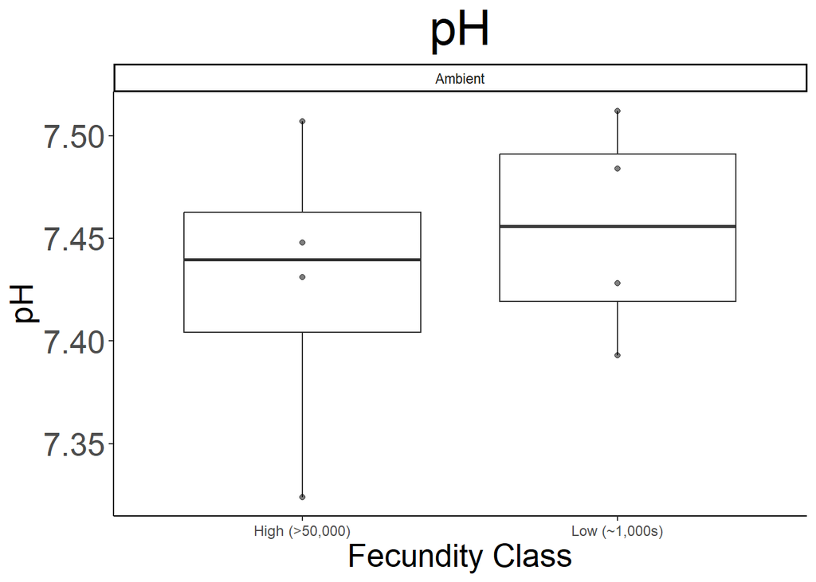

```r
# pH boxplot

# Amb_Fec Samples No Atresia Ids
pH_amb_fec_no_atresia_boxplot <- ggplot(data = Amb_Fec_No_Atresia_Samples) +
  geom_boxplot(aes(x = Fecundity_Class, y = pH)) +
  geom_point(aes(x = Fecundity_Class, y = pH), alpha = 0.5, colour = "black") +
  labs(title = "pH", x = "Fecundity Class", y = "pH") +
   facet_wrap(~ Ambient.Or.OAH) +
  theme_classic() +
  theme(panel.background = element_rect(fill = "white"),
        plot.background = element_rect(fill = "white"),
        legend.background = element_rect(fill = "white", color = "black"),
        title = element_text(size = 12),
        plot.title = element_text(size = 30, hjust = 0.5),
        axis.text.x = element_text(size = 9),
        axis.text.y = element_text(size = 20),
        axis.title.x = element_text(size = 20),
        axis.title.y = element_text(size = 20))

print(pH_amb_fec_no_atresia_boxplot)
```

```r
ggsave(filename = "data-images/pH_amb_fec_no_atresia_boxplot.pdf", plot = pH_amb_fec_no_atresia_boxplot, device = "pdf")
ggsave(filename = "data-images/pH_amb_fec_no_atresia_boxplot.png", plot = pH_amb_fec_no_atresia_boxplot, device = "png")
```

pH Boxplot

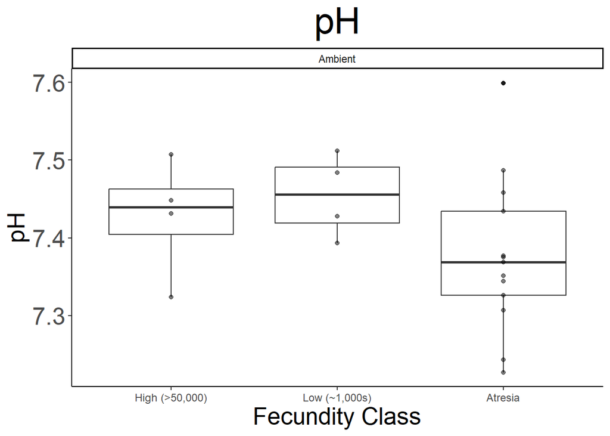

```r
# pH boxplot

# Amb_Fec Samples with Atresia Ids
pH_amb_fec_boxplot <- ggplot(data = Amb_Fec_Samples) +
  geom_boxplot(aes(x = Fecundity_Class, y = pH)) +
  geom_point(aes(x = Fecundity_Class, y = pH), alpha = 0.5, colour = "black") +
  labs(title = "pH", x = "Fecundity Class", y = "pH") +
   facet_wrap(~ Ambient.Or.OAH) +
  theme_classic() +
  theme(panel.background = element_rect(fill = "white"),
        plot.background = element_rect(fill = "white"),
        legend.background = element_rect(fill = "white", color = "black"),
        title = element_text(size = 12),
        plot.title = element_text(size = 30, hjust = 0.5),
        axis.text.x = element_text(size = 9),
        axis.text.y = element_text(size = 20),
        axis.title.x = element_text(size = 20),
        axis.title.y = element_text(size = 20))

print(pH_amb_fec_boxplot)
```

```r
ggsave(filename = "data-images/pH_amb_fec_boxplot.pdf", plot = pH_amb_fec_boxplot, device = "pdf")
ggsave(filename = "data-images/pH_amb_fec_boxplot.png", plot = pH_amb_fec_boxplot, device = "png")
```

pH Parametric Assessment Data Distribution

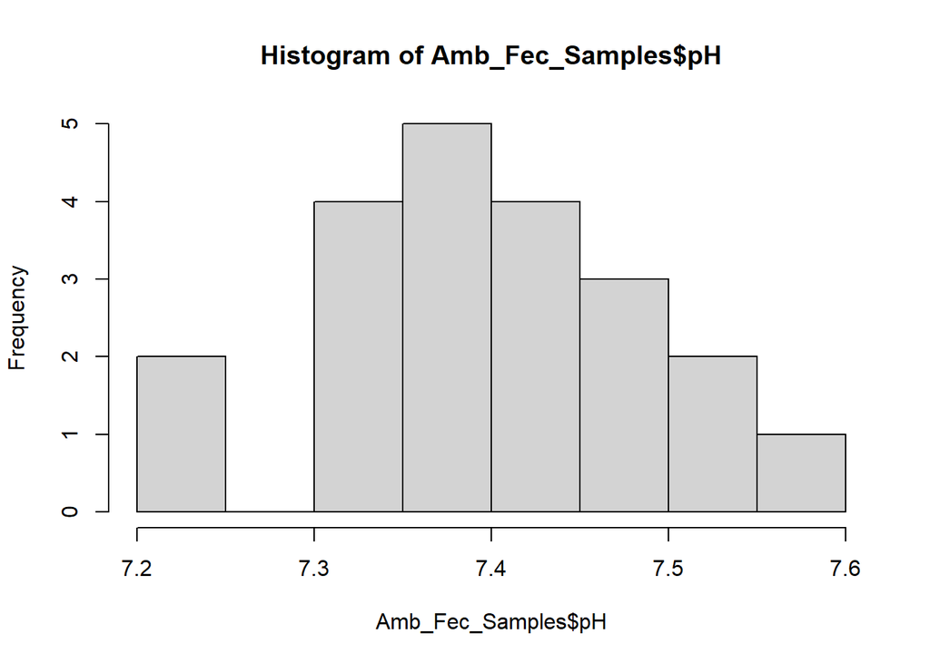

```r
# pH
# Parametric Assumptions

# Data Distribution


# Amb Fec Samples
# Frequency Histograms

hist(Amb_Fec_Samples$pH)
```

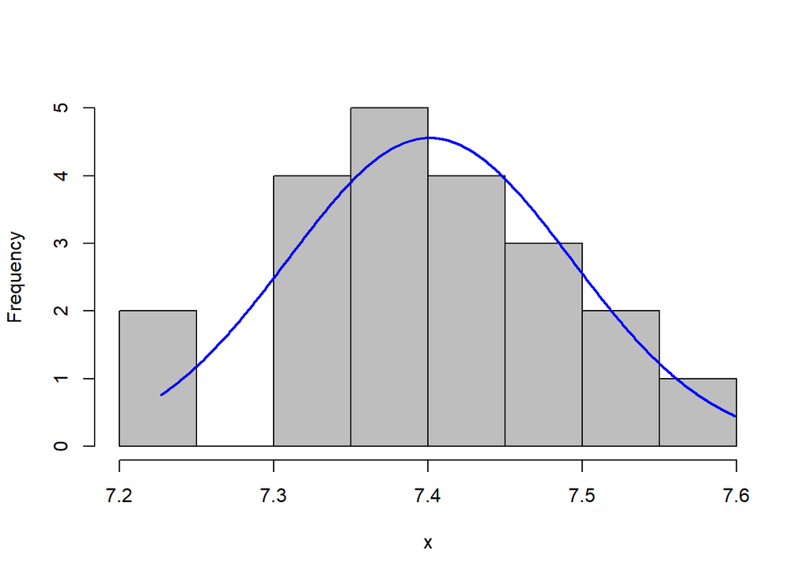

```r
plotNormalHistogram(Amb_Fec_Samples$pH)
```

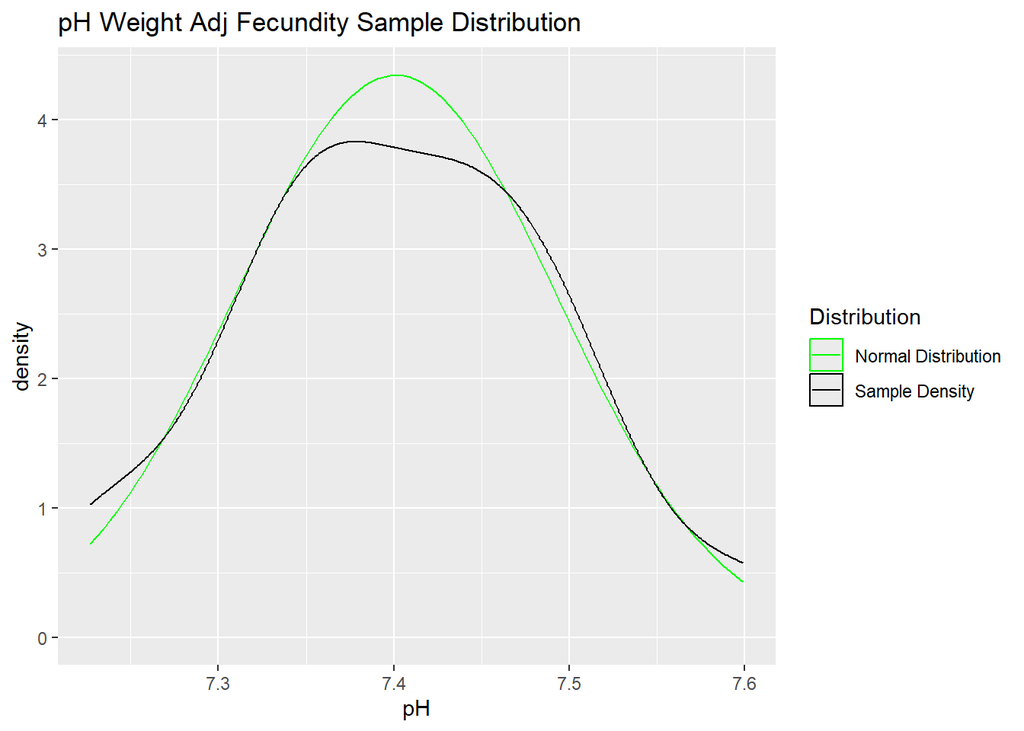

```r
# Density plot

Amb_Fec_Samples %>%
  ggplot(aes(x = pH)) +
  stat_function(fun = dnorm, args = c(mean = mean(Amb_Fec_Samples$pH), sd = sd(Amb_Fec_Samples$pH)), aes(col = "Normal Distribution"), show.legend = TRUE) +
  geom_density(aes(col = "Sample Density"), show.legend = TRUE) +
  labs(title = "pH Weight Adj Fecundity Sample Distribution") +
  scale_color_manual("Distribution", values = c("Normal Distribution" = "green", "Sample Density" = "black"))
```

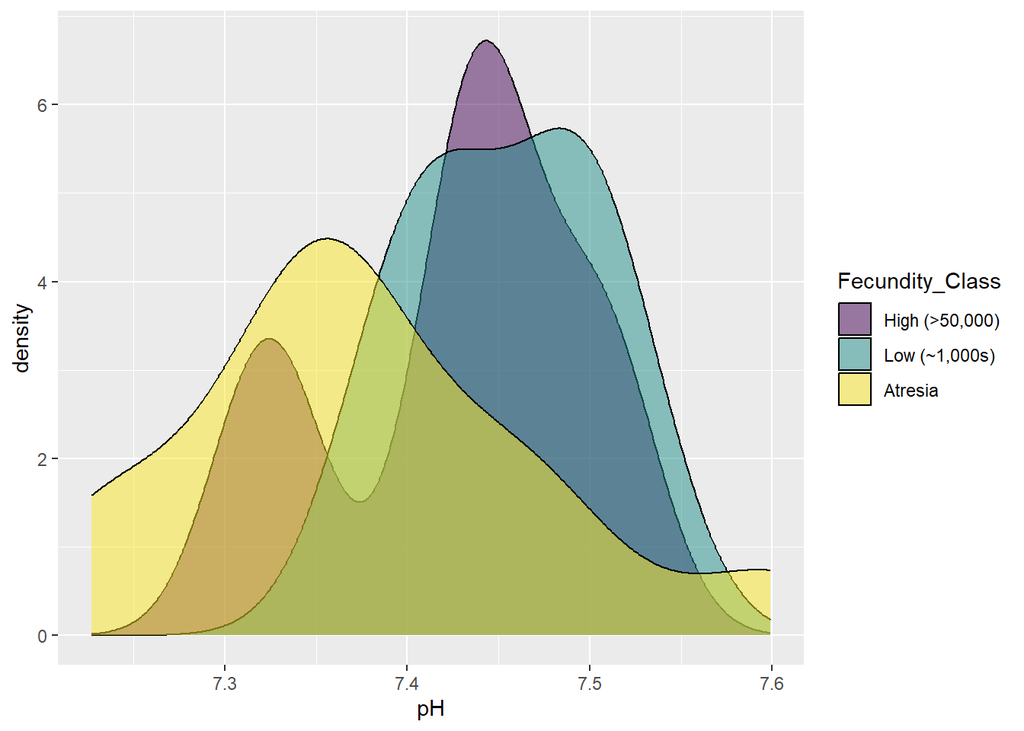

```r
# Density by brood condition
Amb_Fec_Samples %>%
ggplot(aes(x = pH)) +
  geom_density(aes(x = pH, fill = Fecundity_Class), alpha = 0.5)
```

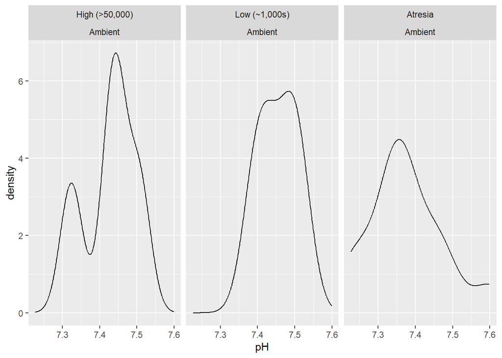

```r
ggplot(Amb_Fec_Samples, aes(x = pH)) +
  geom_density(aes(x = pH)) +
  facet_wrap(Fecundity_Class ~ Ambient.Or.OAH)
```

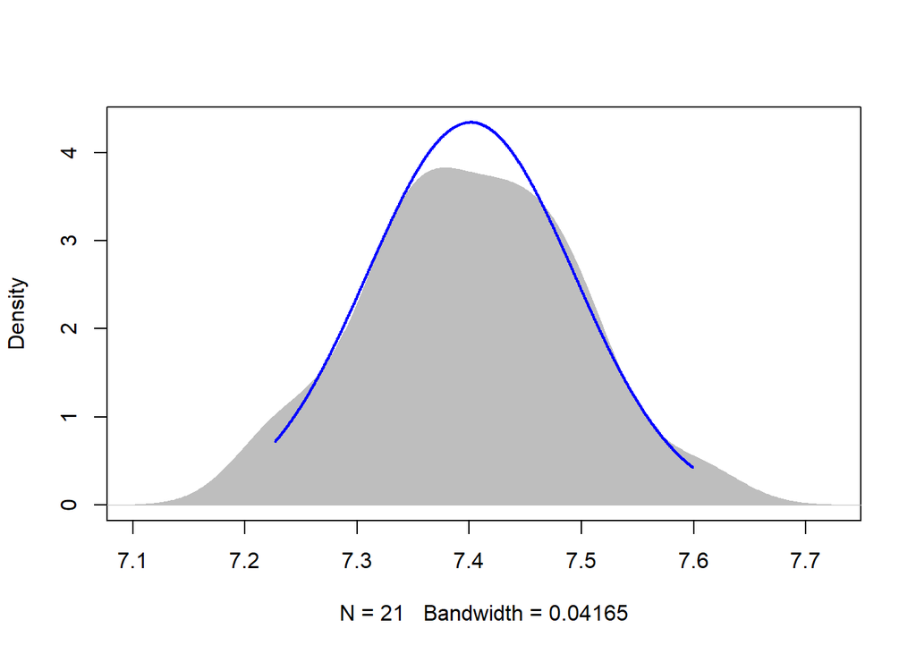

```r
plotNormalDensity(Amb_Fec_Samples$pH)
```

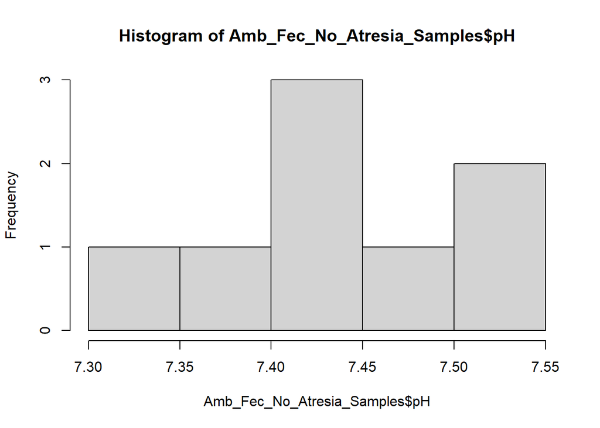

```r
# Amb Fec No Atresia Samples
# Frequency Histograms

hist(Amb_Fec_No_Atresia_Samples$pH)
```

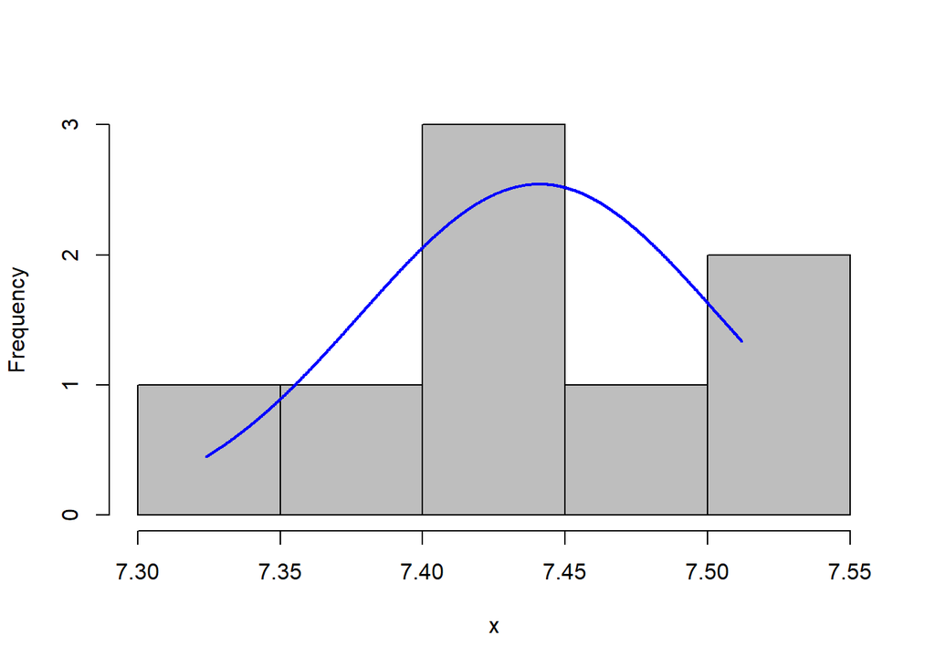

```r
plotNormalHistogram(Amb_Fec_No_Atresia_Samples$pH)
```

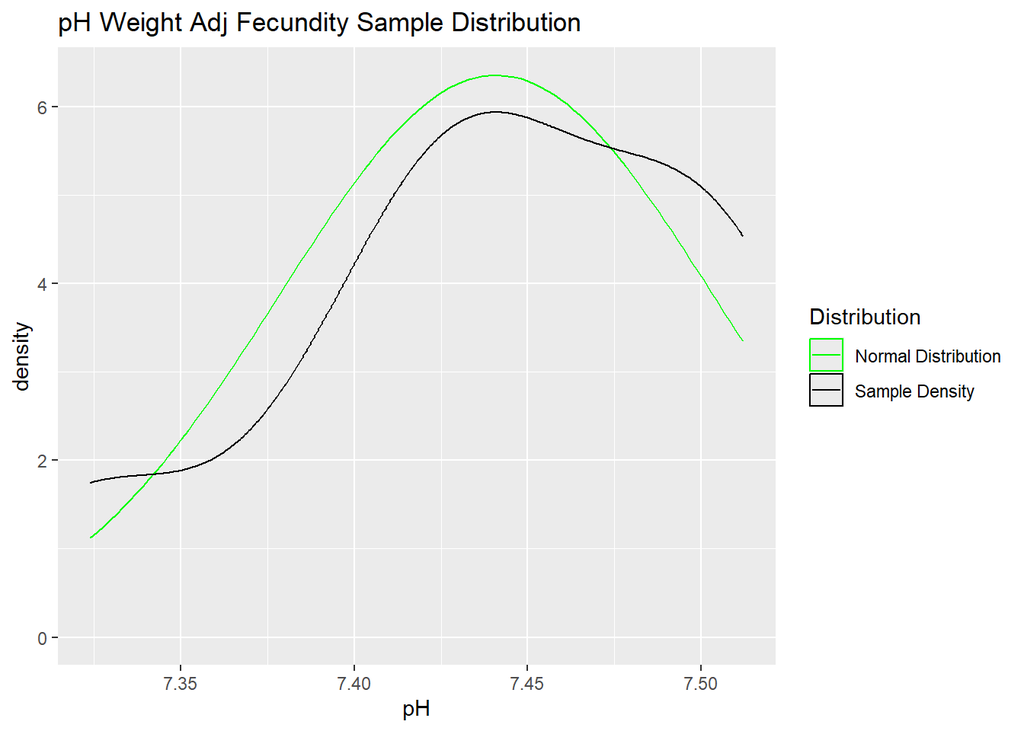

```r
# Density plot

Amb_Fec_No_Atresia_Samples %>%
  ggplot(aes(x = pH)) +
  stat_function(fun = dnorm, args = c(mean = mean(Amb_Fec_No_Atresia_Samples$pH), sd = sd(Amb_Fec_No_Atresia_Samples$pH)), aes(col = "Normal Distribution"), show.legend = TRUE) +
  geom_density(aes(col = "Sample Density"), show.legend = TRUE) +
  labs(title = "pH Weight Adj Fecundity Sample Distribution") +
  scale_color_manual("Distribution", values = c("Normal Distribution" = "green", "Sample Density" = "black"))
```

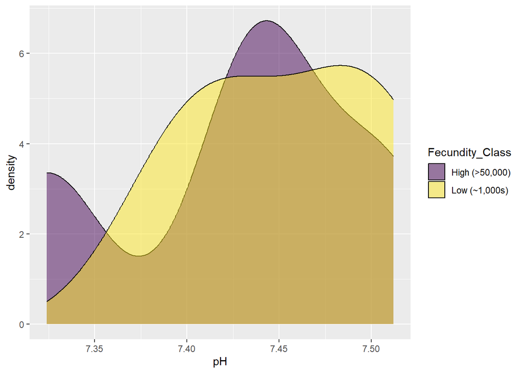

```r
# Density by brood condition
Amb_Fec_No_Atresia_Samples %>%
ggplot(aes(x = pH)) +
  geom_density(aes(x = pH, fill = Fecundity_Class), alpha = 0.5)
```

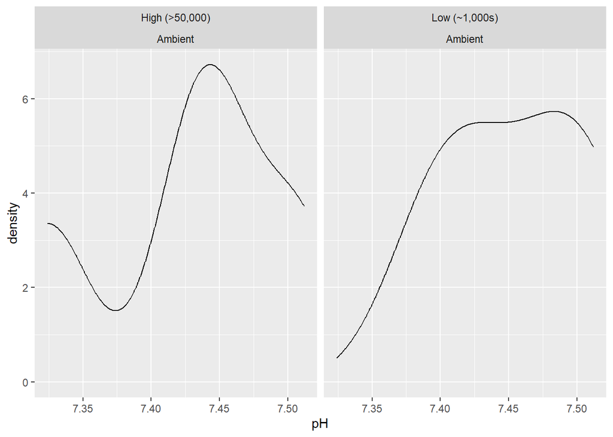

```r
ggplot(Amb_Fec_No_Atresia_Samples, aes(x = pH)) +
  geom_density(aes(x = pH)) +
  facet_wrap(Fecundity_Class ~ Ambient.Or.OAH)
```

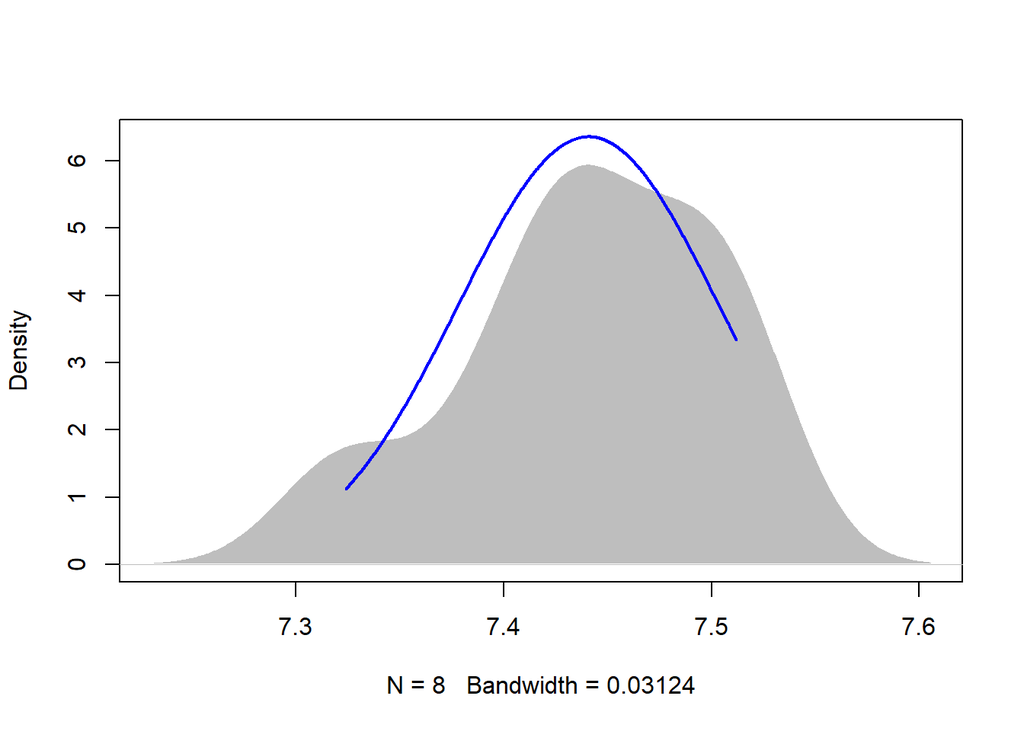

```r
plotNormalDensity(Amb_Fec_No_Atresia_Samples$pH)
```

# pH Stat Tests

Model Design

```r
# pH

# Install flexplot
# devtools::install_github("dustinfife/flexplot", ref="development")
require(flexplot)
# Amb Fec No Atresia regression model

pH_amb_fec_no_atresia_lm <- lm(pH ~ All_Fecundity, data = Amb_Fec_No_Atresia_Samples)

pH_amb_fec_no_atresia_lm_res <- residuals(pH_amb_fec_no_atresia_lm)

# p-value significant if (a < 0.1 or a < 0.05)
summary(pH_amb_fec_no_atresia_lm)
```

```
##
## Call:
## lm(formula = pH ~ All_Fecundity, data = Amb_Fec_No_Atresia_Samples)
##
## Residuals:
##      Min       1Q   Median       3Q      Max
## -0.11708 -0.02362  0.01396  0.03114  0.06929
##
## Coefficients:
##                 Estimate Std. Error t value Pr(>|t|)
## (Intercept)    7.465e+00  5.090e-02 146.673 6.77e-12 ***
## All_Fecundity -4.664e-07  8.660e-07  -0.539     0.61
## ---
## Signif. codes:  0 '***' 0.001 '**' 0.01 '*' 0.05 '.' 0.1 ' ' 1
##
## Residual standard error: 0.06619 on 6 degrees of freedom
## Multiple R-squared:  0.04611,    Adjusted R-squared:  -0.1129
## F-statistic:  0.29 on 1 and 6 DF,  p-value: 0.6096
```

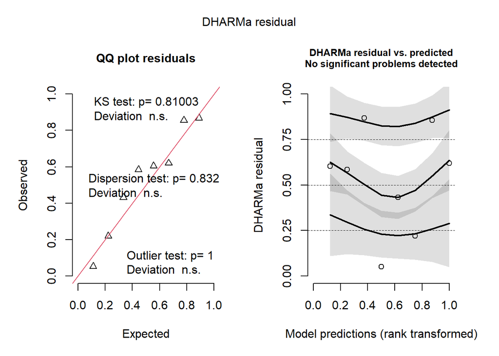

```r
pH_amb_fec_no_atresia_lm_res_plot <- simulateResiduals(fittedModel = pH_amb_fec_no_atresia_lm)
plot(pH_amb_fec_no_atresia_lm_res_plot)
```

```r
shapiro.test(pH_amb_fec_no_atresia_lm_res)
```

```
##
##  Shapiro-Wilk normality test
##
## data:  pH_amb_fec_no_atresia_lm_res
## W = 0.91988, p-value = 0.4289
```

```r
# scedasticity test requires a categorical variable
```

Results: Ambient Fecundity No Atresia Sample

Parametric Assumptions: Across Sample comparisons…

- Sample size (n > 30): **Not Met**
- Normality: **Met**
- Homoscedasticity: **???**

Residuals Plot (if significant)

```r
# pH
# ggplot with geom_smooth(aes(x=,y=)), method = "lm")
```

Model For Fecundity Class

```r
# pH
# Amb Fec No Atresia Class regression model

pH_amb_fec_no_atresia_aov_cat <- aov(pH ~ Fecundity_Class, data = Amb_Fec_No_Atresia_Samples)

summary(pH_amb_fec_no_atresia_aov_cat)
```

```
##                 Df   Sum Sq  Mean Sq F value Pr(>F)
## Fecundity_Class  1 0.001431 0.001431   0.329  0.587
## Residuals        6 0.026126 0.004354
```

```r
TukeyHSD(pH_amb_fec_no_atresia_aov_cat)
```

```
##   Tukey multiple comparisons of means
##     95% family-wise confidence level
##
## Fit: aov(formula = pH ~ Fecundity_Class, data = Amb_Fec_No_Atresia_Samples)
##
## $Fecundity_Class
##                                 diff         lwr       upr     p adj
## Low (~1,000s)-High (>50,000) 0.02675 -0.08742264 0.1409226 0.5872711
```

```r
# Normality test
shapiro.test(Amb_Fec_No_Atresia_Samples$pH)
```

```
##
##  Shapiro-Wilk normality test
##
## data:  Amb_Fec_No_Atresia_Samples$pH
## W = 0.93569, p-value = 0.5693
```

```r
# Parametric variance test:
bartlett.test(pH ~ Fecundity_Class, data = Amb_Fec_No_Atresia_Samples)
```

```
##
##  Bartlett test of homogeneity of variances
##
## data:  pH by Fecundity_Class
## Bartlett's K-squared = 0.30998, df = 1, p-value = 0.5777
```

```r
# Nonparametric variance test:
# Levene's test requires a categorical variable
#LeveneTest(pH ~ Fecundity_Class, data = Amb_Fec_No_Atresia_Samples)
```

Results: Ambient Fecundity No Atresia Sample

- No significant difference in pH between fecundity classes: Low (~1,000s) vs. High (>50,000) (p adj = 0.5872711)

Parametric Assumptions: Across Sample comparisons…

- Sample size (n > 30): **Not Met**
- Normality: **Met**
- Homoscedasticity: **Met**

Model For Fecundity Class (With Atresia)

```r
# pH
# Amb Fec Class regression model

pH_amb_fec_aov_cat <- aov(pH ~ Fecundity_Class, data = Amb_Fec_Samples)

summary(pH_amb_fec_aov_cat)
```

```
##                 Df  Sum Sq  Mean Sq F value Pr(>F)
## Fecundity_Class  2 0.02183 0.010916   1.336  0.288
## Residuals       18 0.14711 0.008173
```

```r
TukeyHSD(pH_amb_fec_aov_cat)
```

```
##   Tukey multiple comparisons of means
##     95% family-wise confidence level
##
## Fit: aov(formula = pH ~ Fecundity_Class, data = Amb_Fec_Samples)
##
## $Fecundity_Class
##                                     diff        lwr        upr     p adj
## Low (~1,000s)-High (>50,000)  0.02675000 -0.1363959 0.18989587 0.9084726
## Atresia-High (>50,000)       -0.05080769 -0.1827287 0.08111329 0.5966404
## Atresia-Low (~1,000s)        -0.07755769 -0.2094787 0.05436329 0.3141611
```

```r
# Normality test:
shapiro.test(Amb_Fec_Samples$pH)
```

```
##
##  Shapiro-Wilk normality test
##
## data:  Amb_Fec_Samples$pH
## W = 0.98534, p-value = 0.9808
```

```r
# Parametric variance test:
bartlett.test(pH ~ Fecundity_Class, data = Amb_Fec_Samples)
```

```
##
##  Bartlett test of homogeneity of variances
##
## data:  pH by Fecundity_Class
## Bartlett's K-squared = 1.4521, df = 2, p-value = 0.4838
```

```r
# Nonparametric variance test:
# Levene's test requires a categorical variable
#LeveneTest(pH ~ Fecundity_Class, data = Amb_Fec_Samples)
```

Results: Ambient Fecundity Sample (With Atresia)

- No significant difference in pH between fecundity classes: Low (~1,000s), High (>50,000), and Atresia
- Evidence: Pr(>F) = 0.288

Parametric Assumptions: Across Sample comparisons…

- Sample size (n > 30): **Not Met**
- Normality: **Met**
- Homoscedasticity: **Met**

Test For Outliers if warranted

```r
# Test for Outliers
```

# Hct : Hematocrit

Hct Summary Stats

```r
# hct
# Summary stats

# Amb Fec data (with atresia IDs)
Amb_Fec_Samples %>%
  group_by(Ambient.Or.OAH, Fecundity_Class) %>%
  summarize(count = n(),
            median = round(median(Hct....), 3),
            mean = round(mean(Hct....), 3),
            sd = round(sd(Hct....), 3),
            cv = round(sd(Hct....)/mean(Hct....), 3)) %>%
  ungroup()
```

```
## # A tibble: 3 × 7
##   Ambient.Or.OAH Fecundity_Class count median  mean    sd    cv
##   <chr>          <ord>           <int>  <dbl> <dbl> <dbl> <dbl>
## 1 Ambient        High (>50,000)      4   16.4  16.7  4.12 0.247
## 2 Ambient        Low (~1,000s)       4   13.4  13.3  2.70 0.203
## 3 Ambient        Atresia            13   17.3  18.2  2.33 0.128
```

```r
# Amb Fec No Atresia data
Amb_Fec_No_Atresia_Samples %>%
  group_by(Ambient.Or.OAH, Fecundity_Class) %>%
  summarize(count = n(),
            median = round(median(Hct....), 3),
            mean = round(mean(Hct....), 3),
            sd = round(sd(Hct....), 3),
            cv = round(sd(Hct....)/mean(Hct....), 3)) %>%
  ungroup()
```

```
## # A tibble: 2 × 7
##   Ambient.Or.OAH Fecundity_Class count median  mean    sd    cv
##   <chr>          <ord>           <int>  <dbl> <dbl> <dbl> <dbl>
## 1 Ambient        High (>50,000)      4   16.4  16.7  4.12 0.247
## 2 Ambient        Low (~1,000s)       4   13.4  13.3  2.70 0.203
```

Data Graphs:

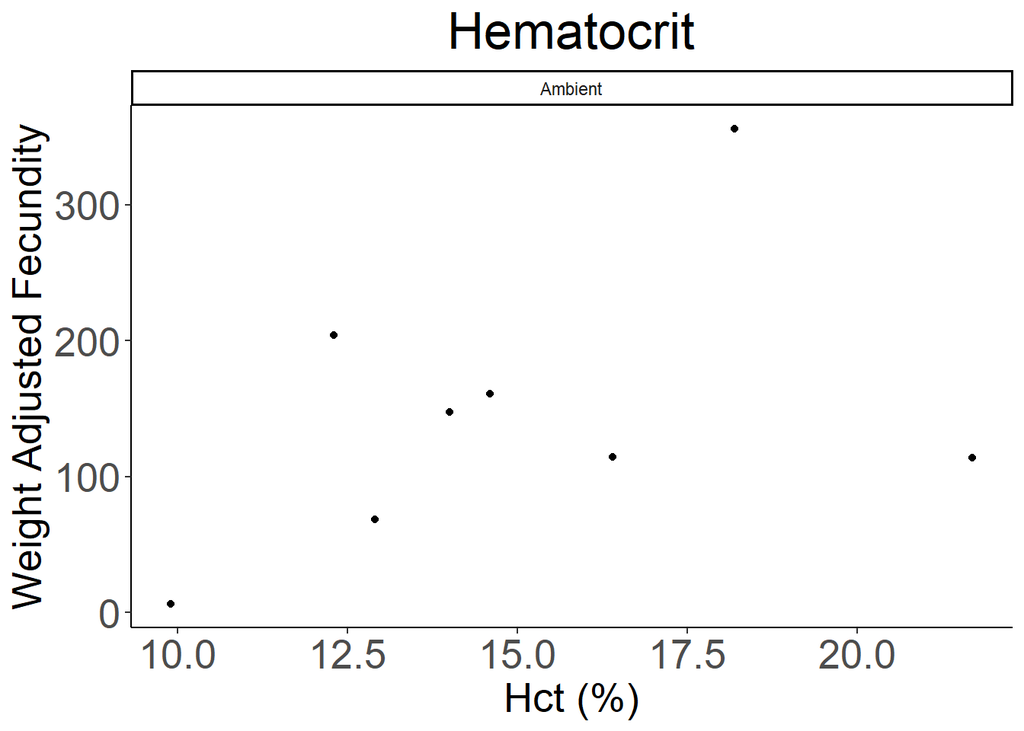

```r
# Hct
# Weight adjusted scatterplot

# Amb Fec only scatterplot: atresia ids removed
hct_amb_fec_no_atresia_weight_adj_scatterplot <- ggplot(data = Amb_Fec_No_Atresia_Samples) +
  geom_point(aes(x = Hct...., y = Weight_Adjusted_Fecundity_Fecundity.Mean_Weight), colour = "black") +
  labs(title = "Hematocrit", x = "Hct (%)", y = "Weight Adjusted Fecundity") +
  scale_y_continuous() +
  theme_classic() +
  facet_wrap(~ Ambient.Or.OAH) +
  theme(panel.background = element_rect(fill = "white"),
        plot.background = element_rect(fill = "white"),
        legend.background = element_rect(fill = "white", color = "black"),
        plot.title = element_text(size = 25, hjust = 0.5),
        axis.text.x = element_text(size = 20),
        axis.text.y = element_text(size = 20),
        axis.title.x = element_text(size = 20),
        axis.title.y = element_text(size = 20))

print(hct_amb_fec_no_atresia_weight_adj_scatterplot)
```

```r
ggsave(filename = "data-images/hct_amb_fec_no_atresia_weight_adj_scatterplot.pdf", plot = hct_amb_fec_no_atresia_weight_adj_scatterplot, device = "pdf")
ggsave(filename = "data-images/hct_amb_fec_no_atresia_weight_adj_scatterplot.png", plot = hct_amb_fec_no_atresia_weight_adj_scatterplot, device = "png")
```

Hct Boxplot

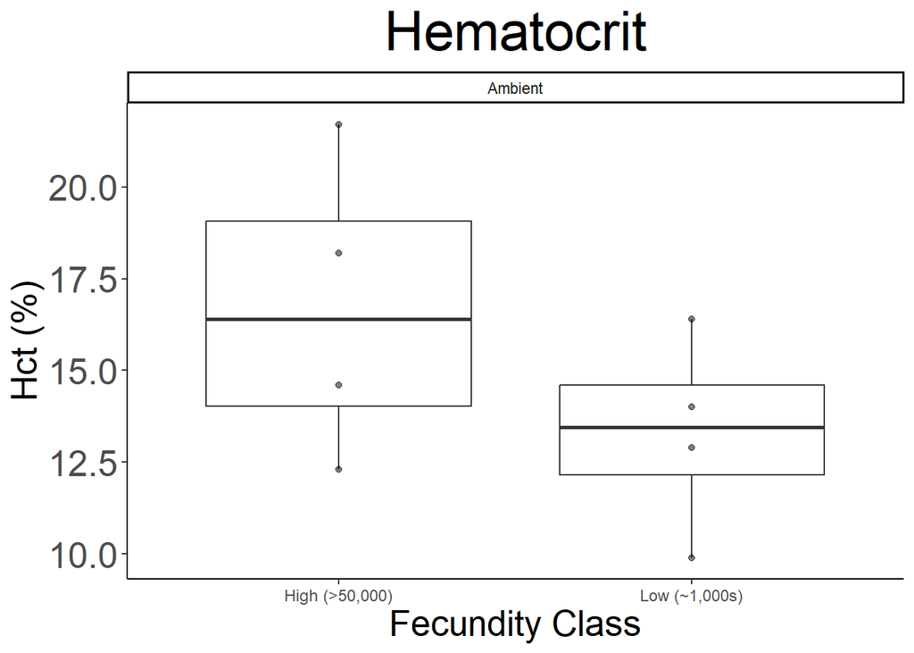

```r
# Hct boxplot

# Amb_Fec Samples No Atresia Ids
hct_amb_fec_no_atresia_boxplot <- ggplot(data = Amb_Fec_No_Atresia_Samples) +
  geom_boxplot(aes(x = Fecundity_Class, y = Hct....)) +
  geom_point(aes(x = Fecundity_Class, y = Hct....), alpha = 0.5, colour = "black") +
  labs(title = "Hematocrit", x = "Fecundity Class", y = "Hct (%)") +
   facet_wrap(~ Ambient.Or.OAH) +
  theme_classic() +
  theme(panel.background = element_rect(fill = "white"),
        plot.background = element_rect(fill = "white"),
        legend.background = element_rect(fill = "white", color = "black"),
        title = element_text(size = 12),
        plot.title = element_text(size = 30, hjust = 0.5),
        axis.text.x = element_text(size = 9),
        axis.text.y = element_text(size = 20),
        axis.title.x = element_text(size = 20),
        axis.title.y = element_text(size = 20))

print(hct_amb_fec_no_atresia_boxplot)
```

```r
ggsave(filename = "data-images/hct_amb_fec_no_atresia_boxplot.pdf", plot = hct_amb_fec_no_atresia_boxplot, device = "pdf")
ggsave(filename = "data-images/hct_amb_fec_no_atresia_boxplot.png", plot = hct_amb_fec_no_atresia_boxplot, device = "png")
```

Hct Boxplot

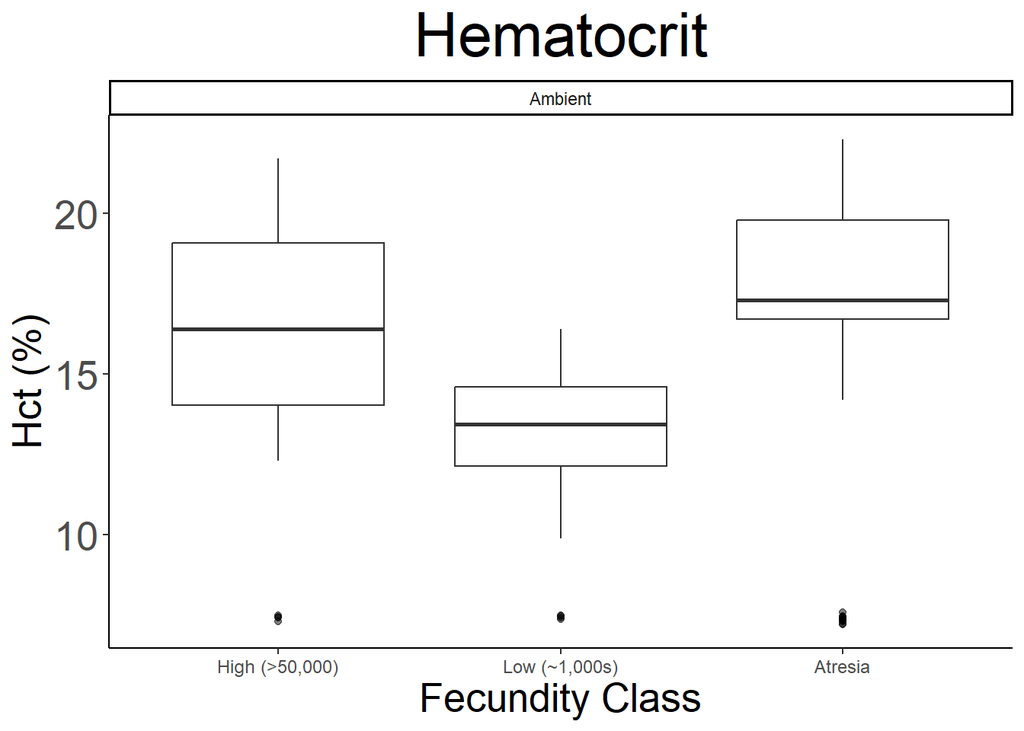

```r
# Hct boxplot

# Amb_Fec Samples with Atresia Ids
hct_amb_fec_boxplot <- ggplot(data = Amb_Fec_Samples) +
  geom_boxplot(aes(x = Fecundity_Class, y = Hct....)) +
  geom_point(aes(x = Fecundity_Class, y = pH), alpha = 0.5, colour = "black") +
  labs(title = "Hematocrit", x = "Fecundity Class", y = "Hct (%)") +
   facet_wrap(~ Ambient.Or.OAH) +
  theme_classic() +
  theme(panel.background = element_rect(fill = "white"),
        plot.background = element_rect(fill = "white"),
        legend.background = element_rect(fill = "white", color = "black"),
        title = element_text(size = 12),
        plot.title = element_text(size = 30, hjust = 0.5),
        axis.text.x = element_text(size = 9),
        axis.text.y = element_text(size = 20),
        axis.title.x = element_text(size = 20),
        axis.title.y = element_text(size = 20))

print(hct_amb_fec_boxplot)
```

```r
ggsave(filename = "data-images/hct_amb_fec_boxplot.pdf", plot = hct_amb_fec_boxplot, device = "pdf")
ggsave(filename = "data-images/hct_amb_fec_boxplot.png", plot = hct_amb_fec_boxplot, device = "png")
```

Hct Parametric Assessment Data Distribution

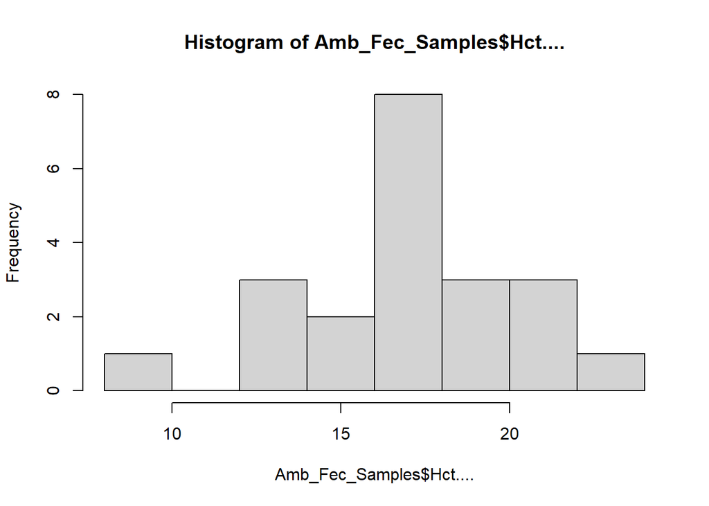

```r
# hct
# Parametric Assumptions

# Data Distribution


# Amb Fec Samples
# Frequency Histograms

hist(Amb_Fec_Samples$Hct....)
```

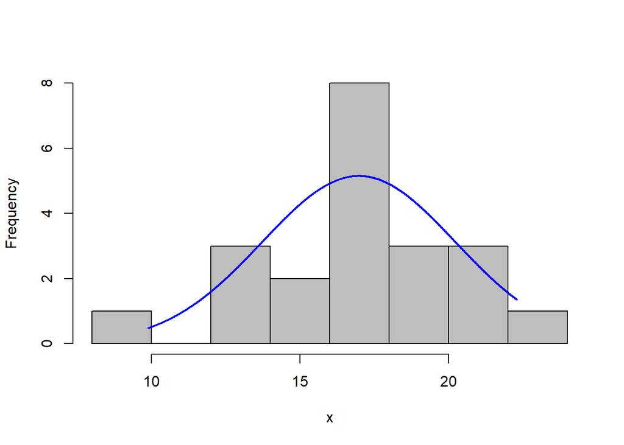

```r
plotNormalHistogram(Amb_Fec_Samples$Hct....)
```

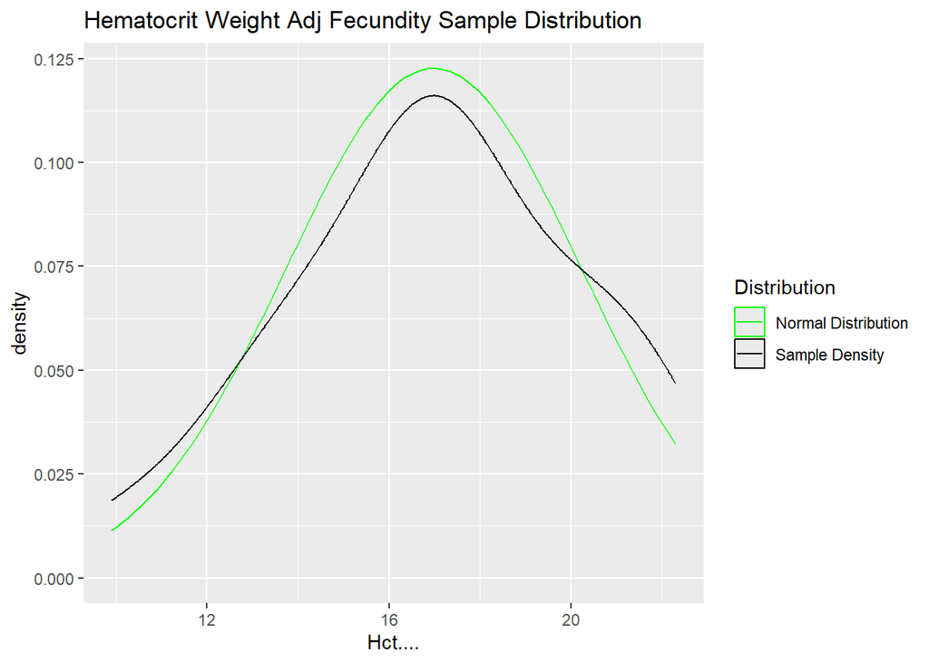

```r
# Density plot

Amb_Fec_Samples %>%
  ggplot(aes(x = Hct....)) +
  stat_function(fun = dnorm, args = c(mean = mean(Amb_Fec_Samples$Hct....), sd = sd(Amb_Fec_Samples$Hct....)), aes(col = "Normal Distribution"), show.legend = TRUE) +
  geom_density(aes(col = "Sample Density"), show.legend = TRUE) +
  labs(title = "Hematocrit Weight Adj Fecundity Sample Distribution") +
  scale_color_manual("Distribution", values = c("Normal Distribution" = "green", "Sample Density" = "black"))
```

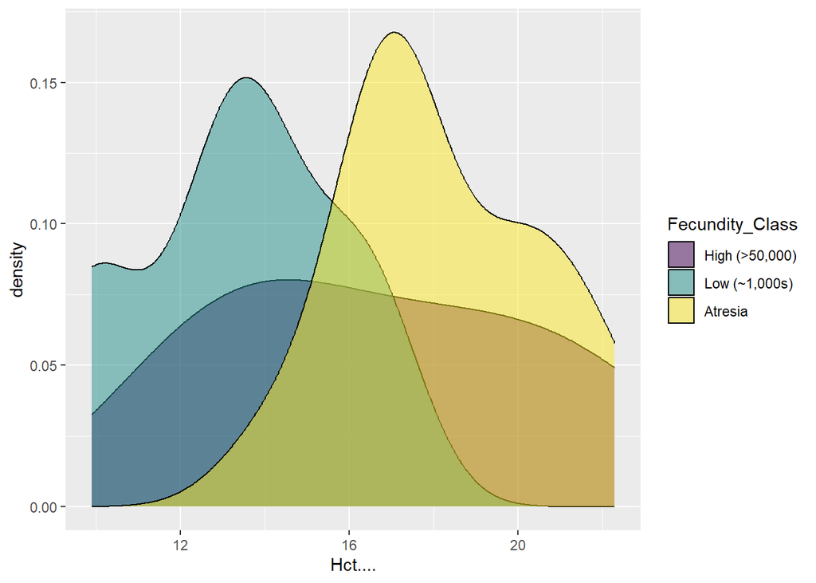

```r
# Density by brood condition
Amb_Fec_Samples %>%
ggplot(aes(x = Hct....)) +
  geom_density(aes(x = Hct...., fill = Fecundity_Class), alpha = 0.5)
```

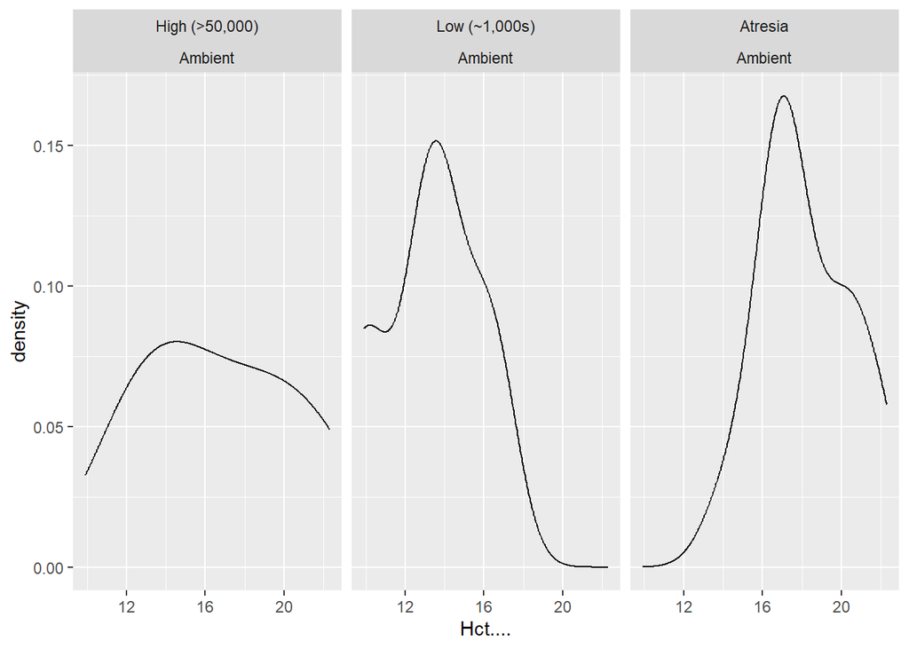

```r
ggplot(Amb_Fec_Samples, aes(x = Hct....)) +
  geom_density(aes(x = Hct....)) +
  facet_wrap(Fecundity_Class ~ Ambient.Or.OAH)
```

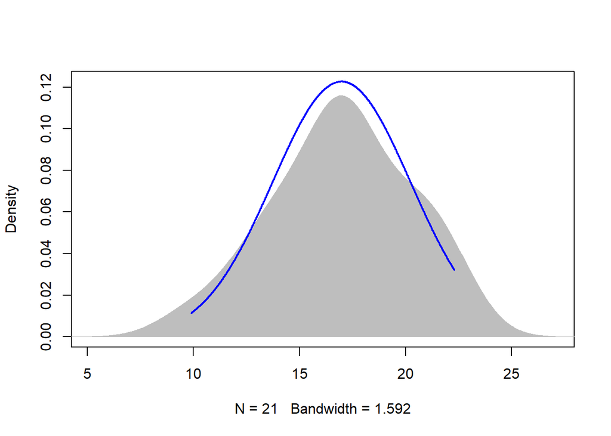

```r
plotNormalDensity(Amb_Fec_Samples$Hct....)
```

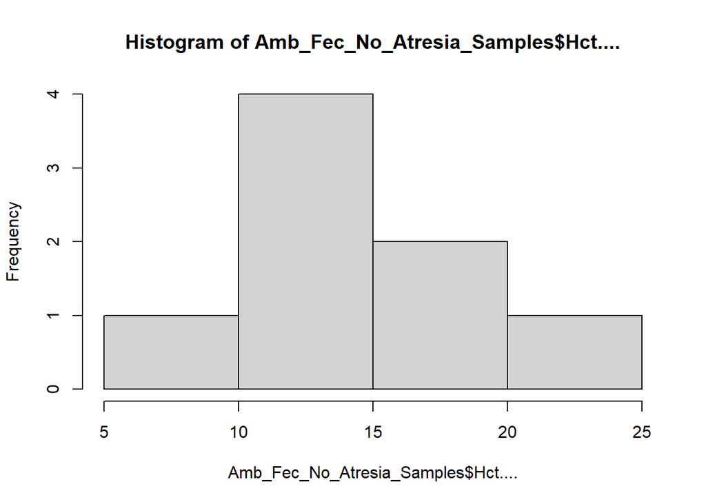

```r
# Hct
# Amb Fec No Atresia Samples
# Frequency Histograms

hist(Amb_Fec_No_Atresia_Samples$Hct....)
```

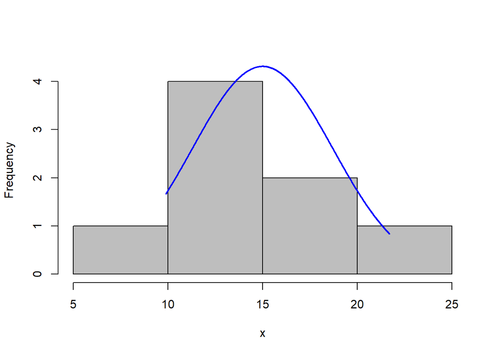

```r
plotNormalHistogram(Amb_Fec_No_Atresia_Samples$Hct....)
```

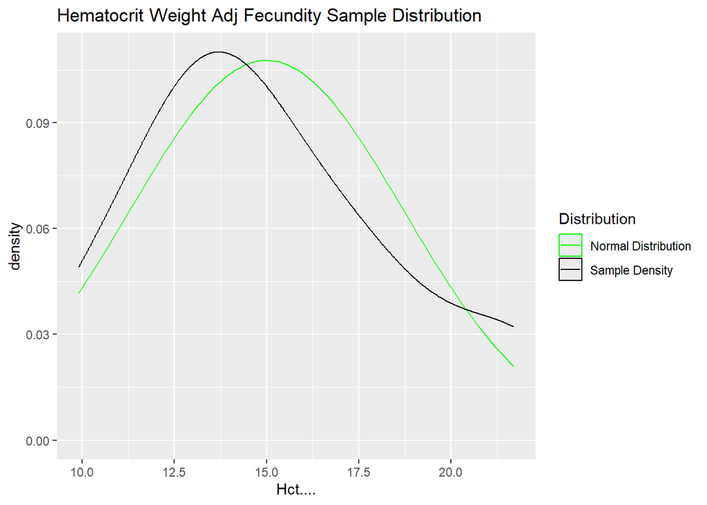

```r
# Density plot

Amb_Fec_No_Atresia_Samples %>%
  ggplot(aes(x = Hct....)) +
  stat_function(fun = dnorm, args = c(mean = mean(Amb_Fec_No_Atresia_Samples$Hct....), sd = sd(Amb_Fec_No_Atresia_Samples$Hct....)), aes(col = "Normal Distribution"), show.legend = TRUE) +
  geom_density(aes(col = "Sample Density"), show.legend = TRUE) +
  labs(title = "Hematocrit Weight Adj Fecundity Sample Distribution") +
  scale_color_manual("Distribution", values = c("Normal Distribution" = "green", "Sample Density" = "black"))
```